# Block 2 ex 7

Facchin Tommaso

The EdenRainfall dataset contains information on rainfall recorded in the Eden River basin, in northern England. The dataset includes the following variables:

- **month**: the month to which the observation refers
- **year**: the year to which the observation refers
- **ndays_prec**: the number of days in the month with precipitation greater than 1 mm
- **high_prec**: an indicator variable equal to 1 if an extreme precipitation event was recorded in the month
- **tot_prec**: total precipitation accumulated during the month
- **mean_prec**: average precipitation accumulated during the month
- **tdays**: total number of days with valid records for the reference month
- **nao**: value of the North Atlantic Oscillation (NAO) index for the month
- **soi**: value of the Southern Oscillation Index (SOI) for the month.

```r
dex <- read.table("../Datasets/EdenRainfall.txt", sep="\t", header = TRUE)
head(dex)
```

```
##   month year ndays_prec high_prec tot_prec mean_prec tdays   nao   soi
## 1     1 1961         23      TRUE    146.3 4.7193548    31  1.46 -0.43
## 2     1 1962         23      TRUE    194.6 6.2774194    31  2.44  1.72
## 3     1 1963         19     FALSE     25.1 0.8096774    31 -4.09  0.80
## 4     1 1964         16     FALSE     40.6 1.3096774    31  0.93 -0.53
## 5     1 1965         21      TRUE    149.4 4.8193548    31  0.01 -0.52
## 6     1 1966         21     FALSE     61.1 1.9709677    31 -1.01 -1.36
```

### Investigate whether the variables **nao** and **soi** influence the probability of observing at least one day with heavy precipitation (*high_precip*) and the proportion of rainy days in a month for the month of January. First, consider models where the predictors are used individually: create plots that show the estimated impact of each single predictor on the response variable. Then estimate a model in which both predictors are included simultaneously. Create plots that show the impact of each predictor, for different values of the other predictor (for example, at the 10th percentile, the median, and the 90th percentile) on the response variable.

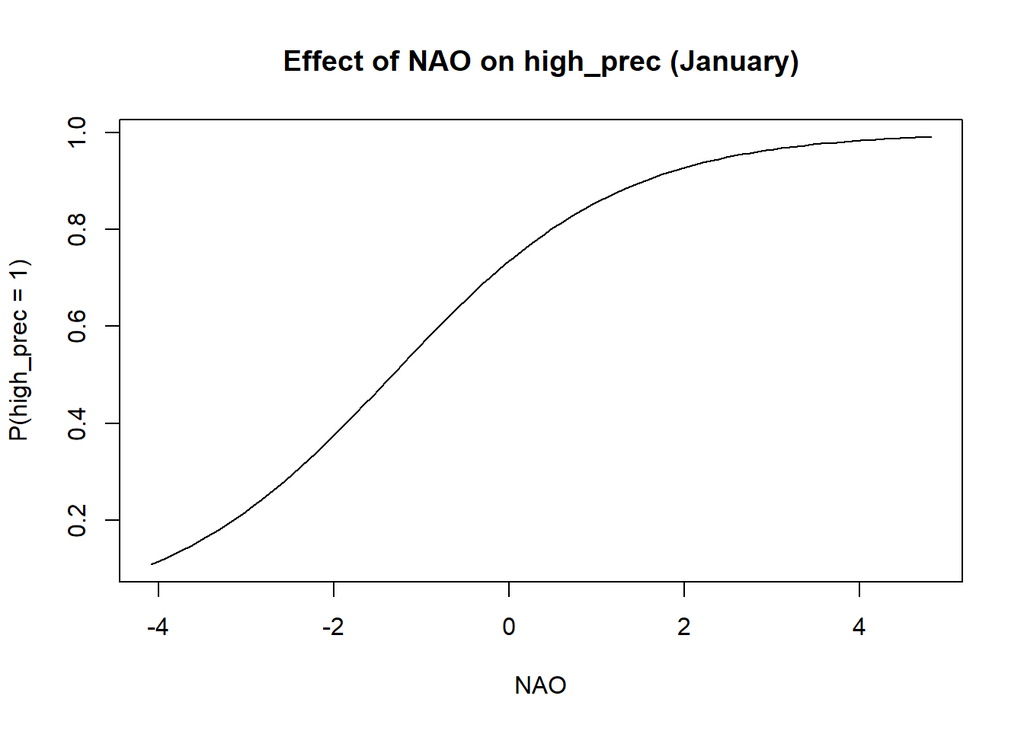

```r
## Filtra il mese di gennaio
jan <- subset(dex, month == 1)

## 1) PROBABILITÀ DI ALMENO UN GIORNO CON PRECIPITAZIONE ELEVATA (high_prec)

## (a) Modelli con un predittore alla volta

# NAO da solo
fit_nao_high <- glm(high_prec ~ nao, data = jan, family = binomial)

# SOI da solo
fit_soi_high <- glm(high_prec ~ soi, data = jan, family = binomial)

# Sequenze di valori per i grafici
nao_seq <- seq(min(jan$nao), max(jan$nao), length.out = 100)
soi_seq <- seq(min(jan$soi), max(jan$soi), length.out = 100)

# Probabilità stimate per NAO
p_nao_high <- predict(fit_nao_high,
                      newdata = data.frame(nao = nao_seq),
                      type = "response")

# Probabilità stimate per SOI
p_soi_high <- predict(fit_soi_high,
                      newdata = data.frame(soi = soi_seq),
                      type = "response")

# Grafico effetto NAO
plot(nao_seq, p_nao_high, type = "l",
     xlab = "NAO", ylab = "P(high_prec = 1)",
     main = "Effect of NAO on high_prec (January)")
```

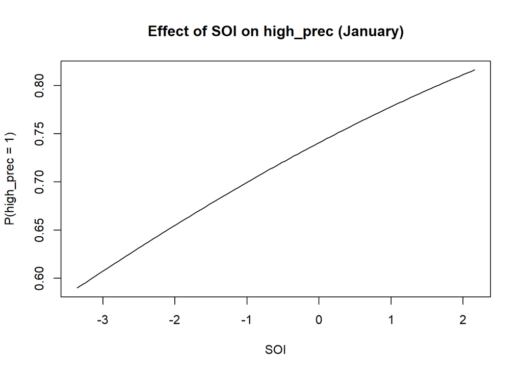

```r
# Grafico effetto SOI
plot(soi_seq, p_soi_high, type = "l",
     xlab = "SOI", ylab = "P(high_prec = 1)",
     main = "Effect of SOI on high_prec (January)")
```

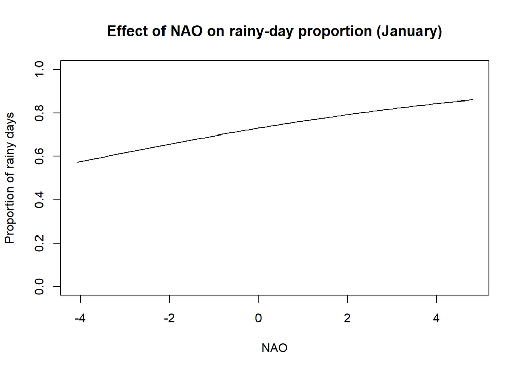

```r
## 2) PROPORZIONE DI GIORNI PIOVOSI NEL MESE

# risposta binomiale: successi = ndays_prec, insuccessi = tdays - ndays_prec
fit_nao_prop <- glm(cbind(ndays_prec, tdays - ndays_prec) ~ nao,
                    data = jan, family = binomial)

fit_soi_prop <- glm(cbind(ndays_prec, tdays - ndays_prec) ~ soi,
                    data = jan, family = binomial)

p_nao_prop <- predict(fit_nao_prop,
                      newdata = data.frame(nao = nao_seq),
                      type = "response")

p_soi_prop <- predict(fit_soi_prop,
                      newdata = data.frame(soi = soi_seq),
                      type = "response")

# Grafico effetto NAO sulla proporzione di giorni piovosi
plot(nao_seq, p_nao_prop, type = "l",
     xlab = "NAO", ylab = "Proportion of rainy days",
     main = "Effect of NAO on rainy-day proportion (January)",
     ylim = c(0, 1))
```

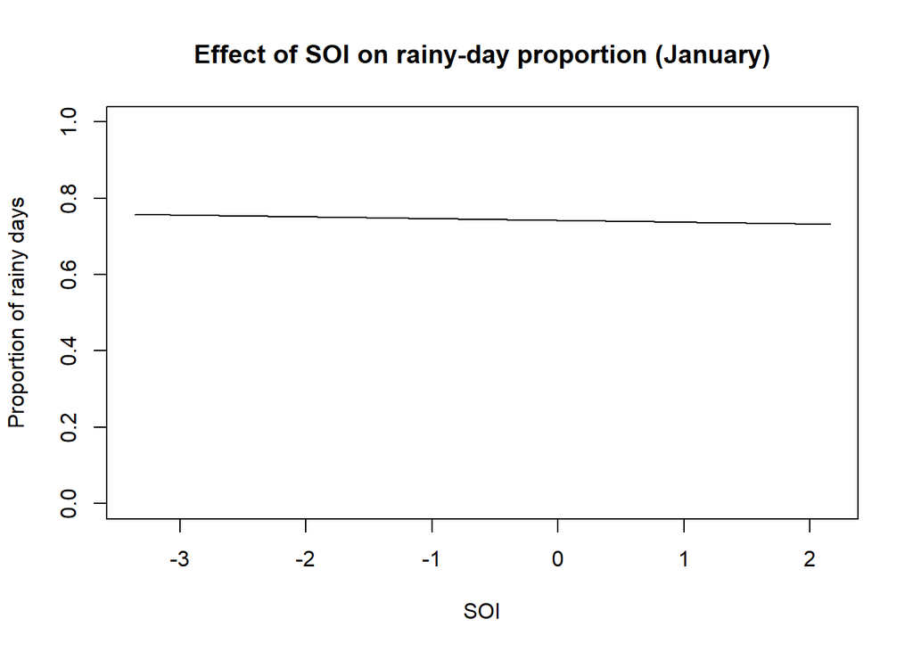

```r
# Grafico effetto SOI sulla proporzione di giorni piovosi
plot(soi_seq, p_soi_prop, type = "l",
     xlab = "SOI", ylab = "Proportion of rainy days",
     main = "Effect of SOI on rainy-day proportion (January)",
     ylim = c(0, 1))
```

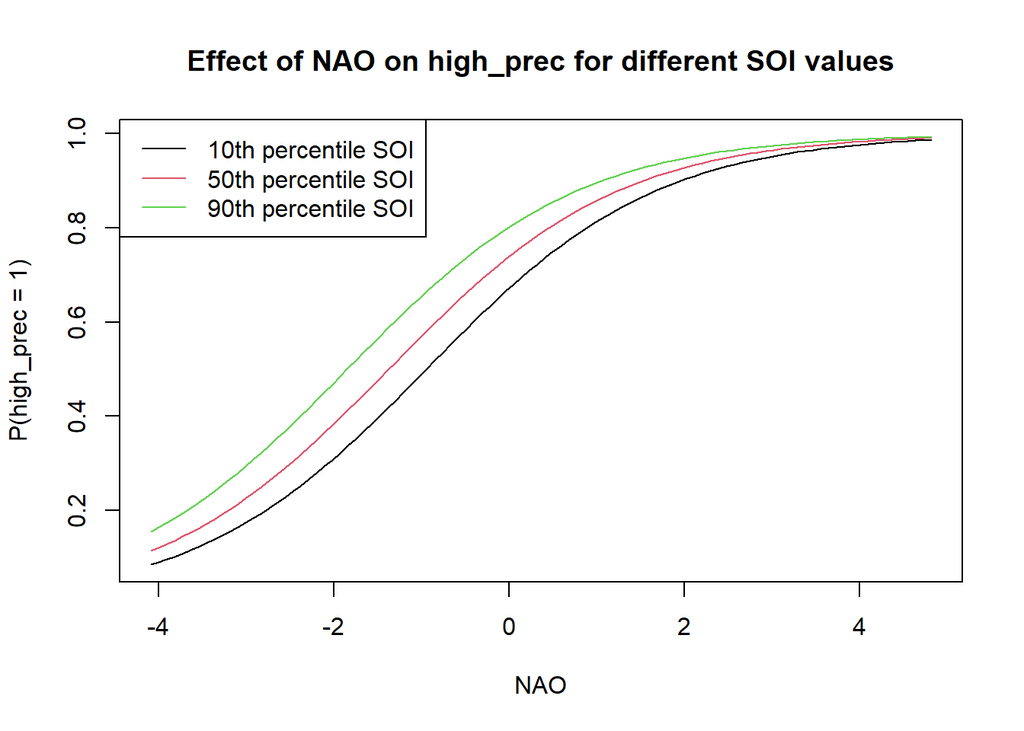

```r
## 3) MODELLI CON ENTRAMBI I PREDITTORI

# high_prec
fit_both_high <- glm(high_prec ~ nao + soi,
                     data = jan, family = binomial)

# proporzione giorni piovosi
fit_both_prop <- glm(cbind(ndays_prec, tdays - ndays_prec) ~ nao + soi,
                     data = jan, family = binomial)


## 4) EFFETTI CON L’ALTRO PREDITTore FISSATO A 10°, MEDIANA, 90°

# Quantili di SOI
q_soi <- quantile(jan$soi, probs = c(0.10, 0.50, 0.90), na.rm = TRUE)
# Quantili di NAO
q_nao <- quantile(jan$nao, probs = c(0.10, 0.50, 0.90), na.rm = TRUE)

## (a) Effetto di NAO per tre valori di SOI – high_prec

p_nao_soi <- sapply(q_soi, function(s) {
  predict(fit_both_high,
          newdata = data.frame(nao = nao_seq, soi = s),
          type = "response")
})

matplot(nao_seq, p_nao_soi, type = "l", lty = 1,
        xlab = "NAO", ylab = "P(high_prec = 1)",
        main = "Effect of NAO on high_prec for different SOI values")
legend("topleft",
       legend = paste(c("10th", "50th", "90th"), "percentile SOI"),
       col = 1:3, lty = 1)
```

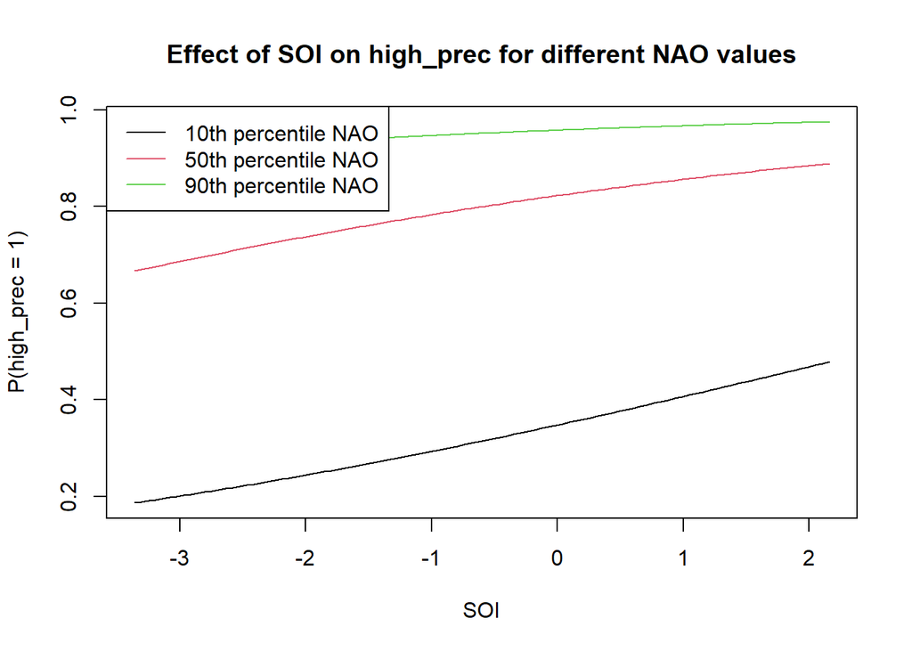

```r
## (b) Effetto di SOI per tre valori di NAO – high_prec

p_soi_nao <- sapply(q_nao, function(n) {
  predict(fit_both_high,
          newdata = data.frame(nao = n, soi = soi_seq),
          type = "response")
})

matplot(soi_seq, p_soi_nao, type = "l", lty = 1,
        xlab = "SOI", ylab = "P(high_prec = 1)",
        main = "Effect of SOI on high_prec for different NAO values")
legend("topleft",
       legend = paste(c("10th", "50th", "90th"), "percentile NAO"),
       col = 1:3, lty = 1)
```